# practical_exercise_2, Methods 3, 2021, autumn semester

## Exercise 2 - comparison of models

1. Build four models and do some comparisons
   1. a single level model that models *f0mn* as dependent on _gender
   2. a two-level model that adds a second level on top of i. where unique intercepts are modelled for each *scenario*
   3. a two-level model that only has *subject* as an intercept’
   4. a two-level model that models intercepts for both *scenario* and *subject*

```r
# i) a single level model that models f0mn as dependent on _gender
m1 <- lm(f0mn~gender, data=politeness)
summary(m1)
```

```
##
## Call:
## lm(formula = f0mn ~ gender, data = politeness)
##
## Residuals:
##      Min       1Q   Median       3Q      Max
## -133.070  -24.128   -6.728   19.530  169.430
##
## Coefficients:
##             Estimate Std. Error t value Pr(>|t|)
## (Intercept)  246.370      3.449   71.43   <2e-16 ***
## genderM     -115.092      5.215  -22.07   <2e-16 ***
## ---
## Signif. codes:  0 '***' 0.001 '**' 0.01 '*' 0.05 '.' 0.1 ' ' 1
##
## Residual standard error: 38.72 on 222 degrees of freedom
## Multiple R-squared:  0.6869, Adjusted R-squared:  0.6855
## F-statistic: 487.1 on 1 and 222 DF,  p-value: < 2.2e-16
```

```r
sigma(m1) # 38.71852
```

```
## [1] 38.71852
```

```r
# ii) a two-level model with scenario as random intercept
m2 <- lmer(f0mn~gender + (1|scenario), data=politeness)
summary(m2)
```

```
## Linear mixed model fit by REML ['lmerMod']
## Formula: f0mn ~ gender + (1 | scenario)
##    Data: politeness
##
## REML criterion at convergence: 2259.7
##
## Scaled residuals:
##     Min      1Q  Median      3Q     Max
## -3.2787 -0.6107 -0.1521  0.5110  4.3331
##
## Random effects:
##  Groups   Name        Variance Std.Dev.
##  scenario (Intercept)   64.64   8.04
##  Residual             1443.22  37.99
## Number of obs: 224, groups:  scenario, 7
##
## Fixed effects:
##             Estimate Std. Error t value
## (Intercept)  246.370      4.549   54.16
## genderM     -115.092      5.117  -22.49
##
## Correlation of Fixed Effects:
##         (Intr)
## genderM -0.492
```

```r
sigma(m2) # 37.98968
```

```
## [1] 37.98968
```

```r
ranef(m2) # extract random effects
```

```
## $scenario
##   (Intercept)
## 1   -8.512646
## 2    4.014190
## 3    4.816792
## 4    8.073595
## 5    1.205885
## 6   -6.211134
## 7   -3.386681
##
## with conditional variances for "scenario"
```

```r
# iii) a a two-level model that only has subject as a random intercept
m3 <- lmer(f0mn~gender+(1|subject),data=politeness)
summary(m3)
```

```
## Linear mixed model fit by REML ['lmerMod']
## Formula: f0mn ~ gender + (1 | subject)
##    Data: politeness
##
## REML criterion at convergence: 2197.5
##
## Scaled residuals:
##     Min      1Q  Median      3Q     Max
## -3.2799 -0.5085 -0.1146  0.3978  3.9225
##
## Random effects:
##  Groups   Name        Variance Std.Dev.
##  subject  (Intercept) 602.0    24.54
##  Residual             967.6    31.11
## Number of obs: 224, groups:  subject, 16
##
## Fixed effects:
##             Estimate Std. Error t value
## (Intercept)  246.370      8.635  28.530
## genderM     -115.092     13.055  -8.816
##
## Correlation of Fixed Effects:
##         (Intr)
## genderM -0.661
```

```r
sigma(m3) # 31.10665
```

```
## [1] 31.10665
```

```r
ranef(m3) # extract random effects
```

```
## $subject
##    (Intercept)
## F1  -10.128483
## F2   10.598952
## F3    4.146857
## F4  -31.042310
## F5   47.414976
## F6  -19.296181
## F7   -6.617313
## F8   -8.161459
## F9   13.084962
## M1   21.317574
## M2   -8.116023
## M3   33.818108
## M4   17.083865
## M5  -27.966947
## M6  -12.097271
## M7  -24.039306
##
## with conditional variances for "subject"
```

```r
# iv) a two-level model that models intercepts for both scenario and subject
m4 <- lmer(f0mn~gender+(1|subject)+(1|scenario),data=politeness)
summary(m4)
```

```
## Linear mixed model fit by REML ['lmerMod']
## Formula: f0mn ~ gender + (1 | subject) + (1 | scenario)
##    Data: politeness
##
## REML criterion at convergence: 2188.8
##
## Scaled residuals:
##     Min      1Q  Median      3Q     Max
## -3.0458 -0.5030 -0.1125  0.4029  3.8668
##
## Random effects:
##  Groups   Name        Variance Std.Dev.
##  subject  (Intercept) 607.40   24.646
##  scenario (Intercept)  81.87    9.048
##  Residual             892.05   29.867
## Number of obs: 224, groups:  subject, 16; scenario, 7
##
## Fixed effects:
##             Estimate Std. Error t value
## (Intercept)  246.370      9.288  26.526
## genderM     -115.092     13.055  -8.816
##
## Correlation of Fixed Effects:
##         (Intr)
## genderM -0.615
```

```r
sigma(m4) # 29.86727
```

```
## [1] 29.86727
```

```r
ranef(m4) # extract random effects
```

```
## $subject
##    (Intercept)
## F1  -10.219298
## F2   10.693985
## F3    4.184039
## F4  -31.320646
## F5   47.840115
## F6  -19.469198
## F7   -6.676646
## F8   -8.234638
## F9   13.202287
## M1   21.508715
## M2   -8.188794
## M3   34.121333
## M4   17.237045
## M5  -28.217708
## M6  -12.205739
## M7  -24.254851
##
## $scenario
##   (Intercept)
## 1  -10.780780
## 2    5.083742
## 3    6.100192
## 4   10.224747
## 5    1.527184
## 6   -7.866047
## 7   -4.289039
##
## with conditional variances for "subject" "scenario"
```

22. which of the models has the lowest residual standard deviation, also compare the Akaike Information Criterion `AIC`?
6. which of the second-level effects explains the most variance?

```r
# Residual standard deviation
tibble(RSD_m1 =sigma(m1),
       RSD_m2 =sigma(m2),
       RSD_m3 =sigma(m3),
       RSD_m4 =sigma(m4))
```

| RSD_m1 | RSD_m2 | RSD_m3 | RSD_m4 |
| --- | --- | --- | --- |
| 38.71852 | 37.98968 | 31.10665 | 29.86727 |

```r
AIC(m1,m2,m3,m4)
```

|  | df | AIC |
| --- | --- | --- |
| m1 | 3 | 2277.706 |
| m2 | 4 | 2267.733 |
| m3 | 4 | 2205.469 |
| m4 | 5 | 2198.778 |

```r
# comparing conditional R2 within the second levels
MuMIn::r.squaredGLMM(m2) #R2c = 0.698216
```

```
##            R2m      R2c
## [1,] 0.6846987 0.698216
```

```r
MuMIn::r.squaredGLMM(m3) #R2c = 0.8002449
```

```
##            R2m       R2c
## [1,] 0.6759677 0.8002449
```

```r
MuMIn::r.squaredGLMM(m4) #R2c = 0.816289
```

```
##            R2m      R2c
## [1,] 0.6743396 0.816289
```

We see that the model with the lowest residual standard deviation is m4 (i.e. the two-level model that models intercepts for both scenario and subject). This model has a residual standard deviation of 29.9 and does also has the lowest AIC value (of 2198.778).

The AIC and residual standard deviation is lower for the model with only the *subject* as random intercept compared to the one with *scenario*. This signifies that model from iii explains the most variance. Also, when comparing only the second-levels effects (model 2 and model 3) by their Conditional R2 (R2c) which states how much variance is explained by both random and fixed effects, it is shown that model 2 has an R2c of 0.698216 and model 3 has an R2c of 0.8002449, and thus stating that the second-level effect “subject” explains the most variance.

2. Why is our single-level model bad?

The short answer is that it doesn’t take individual differences in pitch into account. This will be described more below.

1. create a new data frame that has three variables, *subject*, *gender* and *f0mn*, where *f0mn* is the average of all responses of each subject, i.e. averaging across *attitude* and_scenario_

```r
library(dplyr)

newdf <- politeness[c(1,2,6)] # create df as a subset of politeness df
newdf <- newdf %>%
  group_by(subject) %>%
  mutate(Mean = mean(f0mn)) %>%
  ungroup()

newdf$f0mn <- NULL
newdf <- rename(newdf, f0mn = Mean) # rename the old variable "Mean" and call it "f0mn" instead

head(newdf) # check df
```

| subject | gender | f0mn |
| --- | --- | --- |
| F1 | F | 235.0786 |
| F1 | F | 235.0786 |
| F1 | F | 235.0786 |
| F1 | F | 235.0786 |
| F1 | F | 235.0786 |
| F1 | F | 235.0786 |

2. build a single-level model that models *f0mn* as dependent on *gender* using this new dataset

```r
newmodel <- lm(f0mn ~ gender, data=newdf)
```

3. make Quantile-Quantile plots, comparing theoretical quantiles to the sample quantiles) using `qqnorm` and `qqline` for the new single-level model and compare it to the old single-level model (from 1). Which model’s residuals ($\epsilon$) fulfil the assumptions of the General Linear Model better?)

*QQ-PLOT OF SINGLE LEVEL MODEL:*

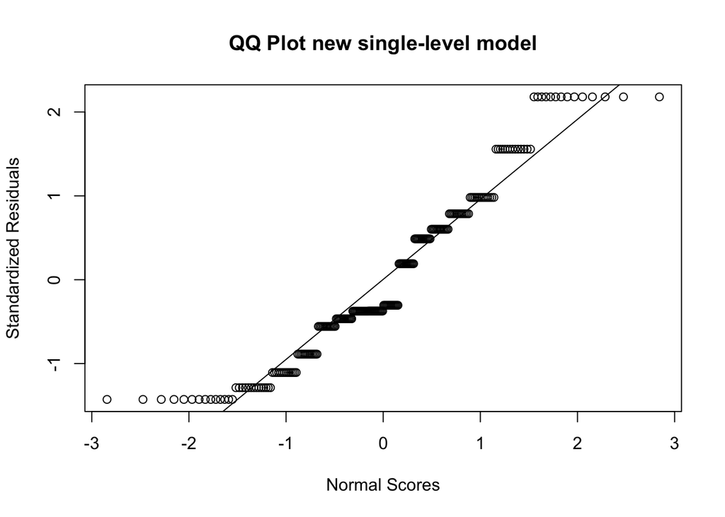

```r
newmodel.stdres <- rstandard(newmodel)

qqnorm(newmodel.stdres,
     ylab="Standardized Residuals",
     xlab="Normal Scores",
     main="QQ Plot new single-level model")
 qqline(newmodel.stdres)
```

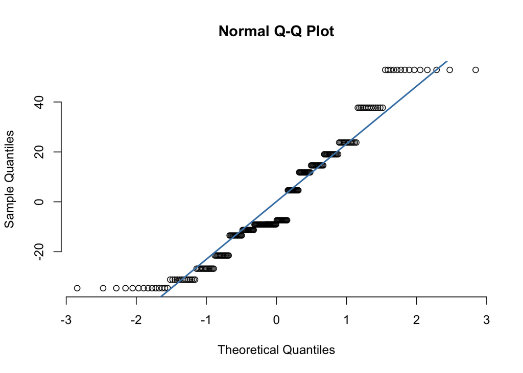

```r
# Same way but more simple code
qqnorm(resid(newmodel),pch = 1, frame = FALSE)
qqline(resid(newmodel),col = "steelblue", lwd = 2)
```

In the above qq-plot, it seems as if the errors are rather systematic - indicating that a linear fit of the data might not be appropriate.

*QQ-PLOT OF MODEL1 (I.E. THE OLD SINGLE-LEVEL MODEL:*

[figure not shown]

```r
oldmodel.stdres <- rstandard(m1)
qqnorm(oldmodel.stdres,
     ylab="Standardized Residuals",
     xlab="Normal Scores",
     main="QQ Plot new single-level model")
 qqline(oldmodel.stdres)
```

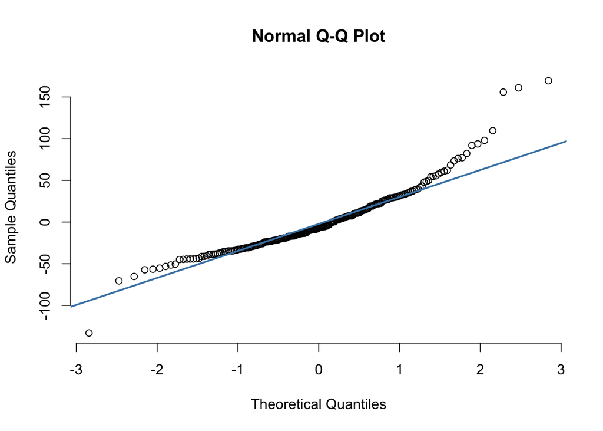

```r
# Same way but more simple code to do a qq-plot of old single level model
qqnorm(resid(m1),pch = 1, frame = FALSE)
qqline(resid(m1),col = "steelblue", lwd = 2)
```

4. Also make a quantile-quantile plot for the residuals of the multilevel model with two intercepts. Does it look alright?

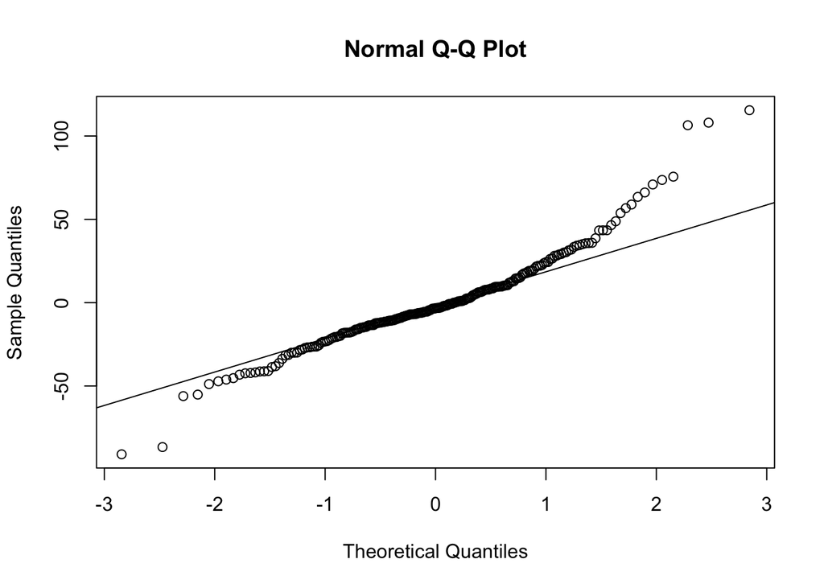

```r
qqnorm(resid(m4))
qqline(resid(m4))
```

From looking at the QQ plots, the old model seems to fulfill the assumptions of the GLM better. However, both the new single-level model and the old single-level model seem to violate the assumption of normally distributed residuals as the both QQ-plots indicates a skewed distributions. Averaging the outcome variable across scenarious discards a lot of potentially usefull information, so in practice, it is not a very informative model.

However, violation of the assumption of normality of residuals is not the most important violation that makes our single level model bad. Our single level model is bad because the repeated measures design violates the assumption of independence that the linear model has. Using a single-level model, the data used to make the model violates the very assumptions upon which our model is build, and thus the model is not very informative. We simply can’t use a single-level model to model data from a repeated measures design (which is the case here) - for that, we need to make a multilevel model, taking both random and fixed effects into account.

The QQ-plot for the residuals of the multilevel model with two intercept looks alright, although the residual distribution seems to be heavy tailed. The QQ-plot for the residuals of model 4 looks a little better than model 1 and the single-level model, but still has a right skewed tail. This violation of normality of residuals can be accepted since linear models are relatively robust against violations of the assumptions of normality. This model does not violate the assumption of independence, which is more important.

3. Plotting the two-intercepts model
   1. Create a plot for each subject, (similar to part 3 in Exercise 1), this time also indicating the fitted value for each of the subjects for each for the scenarios (hint use `fixef` to get the “grand effects” for each gender and `ranef` to get the subject- and scenario-specific effects)

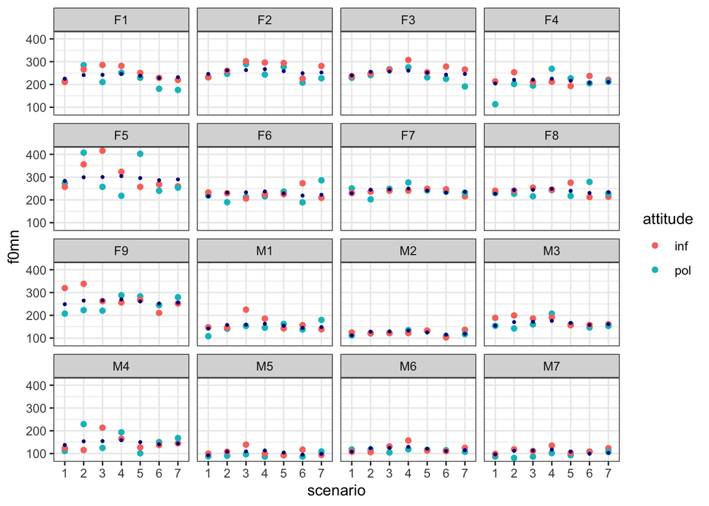

```r
fitted <- fitted(m4)

politeness$fitted_f0mn <- fitted

ggplot(politeness, (aes(x = scenario, y = f0mn, color = attitude)))+
  geom_point()+
  geom_point(aes(scenario, fitted_f0mn), color = "darkblue", size=0.6)+
  facet_wrap(.~subject)+
  theme_bw()
```

In the plot above, the black dots indicate the fitted value for each of the subjects for each of the scenarios. The colored dots indicate the observed values.

## Exercise 3 - now with attitude

1. Carry on with the model with the two unique intercepts fitted (*scenario* and *subject*).
1. now build a model that has *attitude* as a main effect besides *gender*

```r
m5 <- lmer(f0mn~gender+attitude+(1|subject)+(1|scenario),data=politeness)
summary(m5)
```

```
## Linear mixed model fit by REML ['lmerMod']
## Formula: f0mn ~ gender + attitude + (1 | subject) + (1 | scenario)
##    Data: politeness
##
## REML criterion at convergence: 2173.1
##
## Scaled residuals:
##     Min      1Q  Median      3Q     Max
## -2.8861 -0.5948 -0.0981  0.4015  3.9216
##
## Random effects:
##  Groups   Name        Variance Std.Dev.
##  subject  (Intercept) 610.51   24.709
##  scenario (Intercept)  83.23    9.123
##  Residual             848.56   29.130
## Number of obs: 224, groups:  subject, 16; scenario, 7
##
## Fixed effects:
##             Estimate Std. Error t value
## (Intercept)  252.928      9.500  26.624
## genderM     -115.092     13.055  -8.816
## attitudepol  -13.116      3.893  -3.370
##
## Correlation of Fixed Effects:
##             (Intr) gendrM
## genderM     -0.601
## attitudepol -0.205  0.000
```

2. make a separate model that besides the main effects of *attitude* and *gender* also include their interaction

```r
m6 <- lmer(f0mn~gender+attitude+gender:attitude+(1|subject)+(1|scenario),data=politeness)
summary(m6)
```

```
## Linear mixed model fit by REML ['lmerMod']
## Formula: f0mn ~ gender + attitude + gender:attitude + (1 | subject) +
##     (1 | scenario)
##    Data: politeness
##
## REML criterion at convergence: 2166.6
##
## Scaled residuals:
##     Min      1Q  Median      3Q     Max
## -2.8399 -0.5643 -0.0944  0.4264  3.9610
##
## Random effects:
##  Groups   Name        Variance Std.Dev.
##  subject  (Intercept) 610.37   24.71
##  scenario (Intercept)  83.17    9.12
##  Residual             850.50   29.16
## Number of obs: 224, groups:  subject, 16; scenario, 7
##
## Fixed effects:
##                     Estimate Std. Error t value
## (Intercept)          254.193      9.654  26.330
## genderM             -117.983     13.633  -8.654
## attitudepol          -15.646      5.196  -3.011
## genderM:attitudepol    5.781      7.856   0.736
##
## Correlation of Fixed Effects:
##             (Intr) gendrM atttdp
## genderM     -0.618
## attitudepol -0.269  0.191
## gndrM:tttdp  0.178 -0.288 -0.661
```

```r
fixef(m6)
```

```
##         (Intercept)             genderM         attitudepol genderM:attitudepol
##           254.19276          -117.98276           -15.64572             5.78136
```

3. describe what the interaction term in the model says about Korean men’s pitch when they are polite relative to Korean women’s pitch when they are polite (you don’t have to judge whether it is interesting)

First of all, it is important to state that the interation term was not found to be statistically significant at the 5% significance level (as p-value > 0.05), and thus doesn’t justify the inclusion of the term in our model. Moreover, the plot below indicates overlapping error bars, also indicating the absence of a real interaction effect.

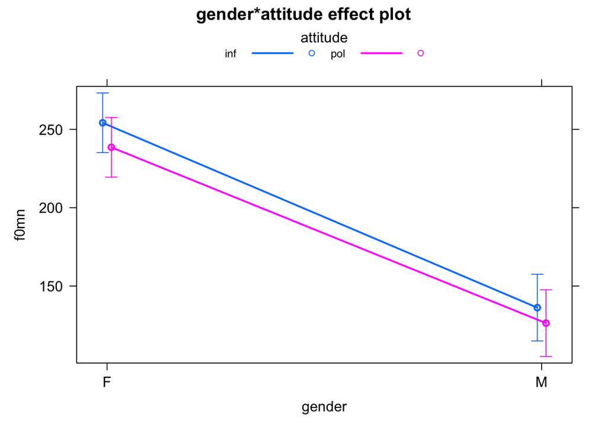

```r
plot(allEffects(m6), multiline=TRUE, ci.style="bars")
```

Nonetheless, the following section will describe the interpretation of the interaction effect, assuming that it was statistically significant.

“Attitudepol” indicates that the pitch generally decreases with -15.646 hz when going from informal to polite